# milestone_3

Evelyn Cai

2/21/2020

## Milestone 3

The article I am replicating is Daniel Smith et. al’s “Identifying voter preferences for politicians’ personal attributes: a conjoint experiment in Japan”. It is about whether voters really do prefer candidates with certain characteristics (immutable or not, such as gender and experience), or whether these preferences are induced by other causes such as PR vs. first-pass-the-post systems or regional vs. national political party organizing. For example, voters may not inherently prefer male candidates over female candidates, but may be induced to choose male candidates because of a first-pass-the-post system, in which there is less coordination among national parties to ensure their party’s candidates are diverse and representative enough. Smith et. al chose a conjoint experimental method, which has recently become very popular in political science, to randomize every characteristic of a fake candidate so that the treatment effect of each characteristic can be parsed out later statistically. Link to the article is here. [Link to the replication files are here.](https://dataverse.harvard.edu/dataset.xhtml?persistentId=doi:10.7910/DVN/KCIADO)

[Link to my public Github repo for final project milestones is here.](https://github.com/caievelyn/milestone)

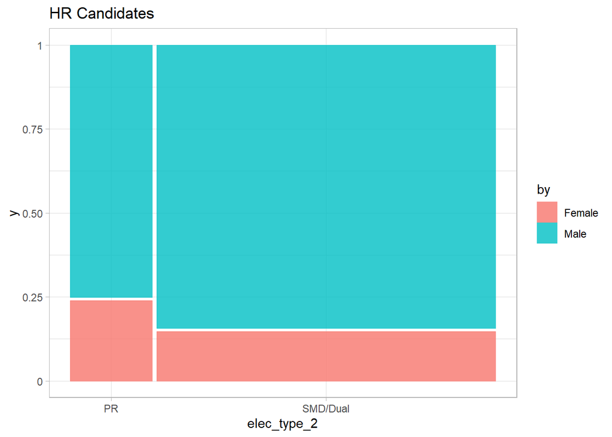

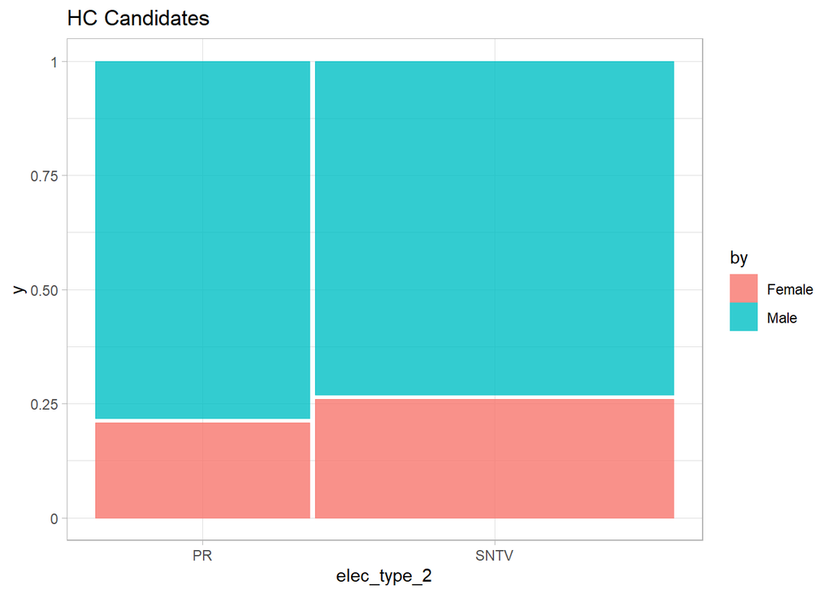

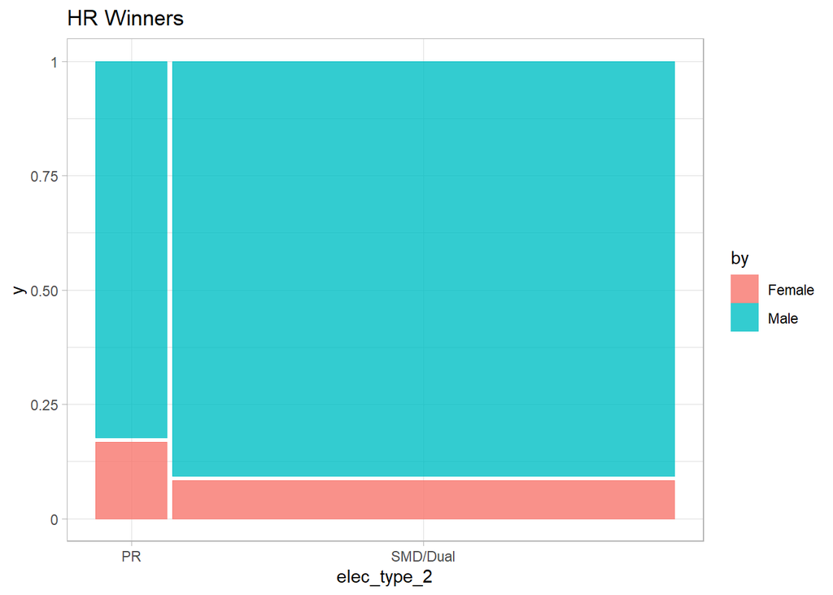

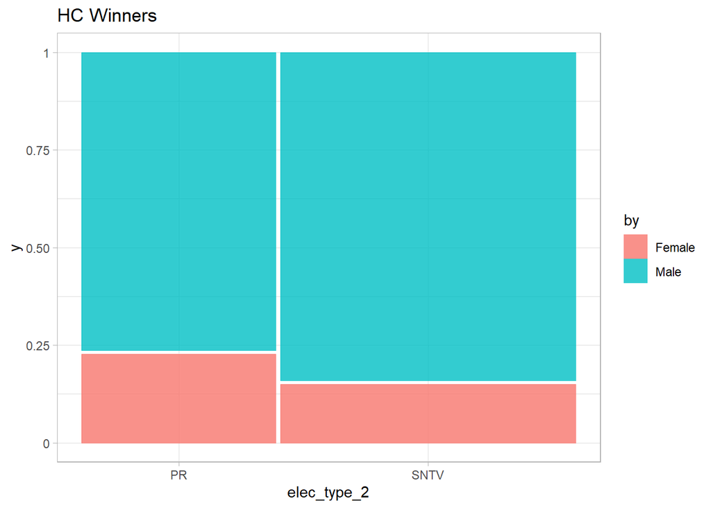

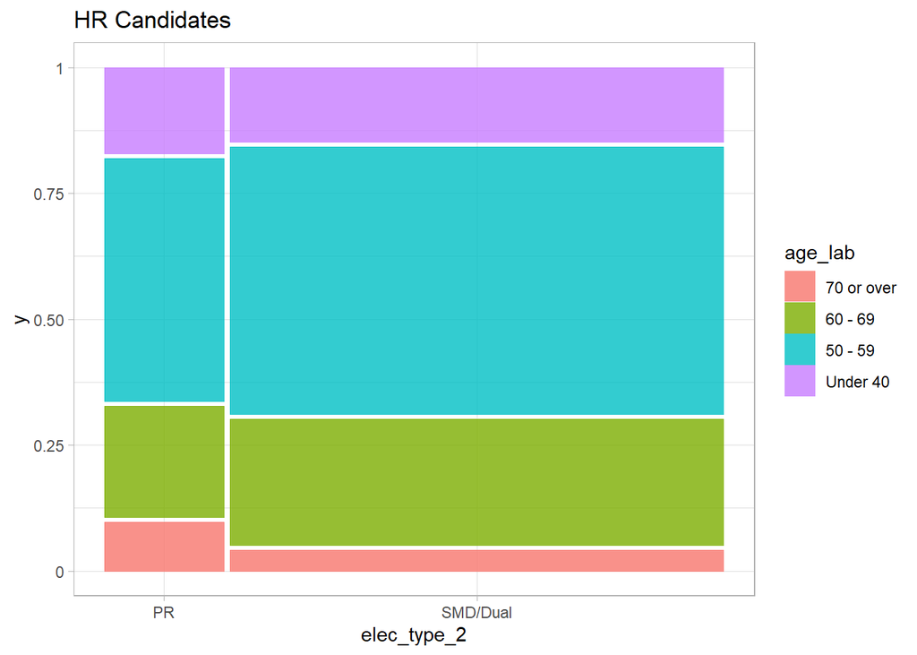

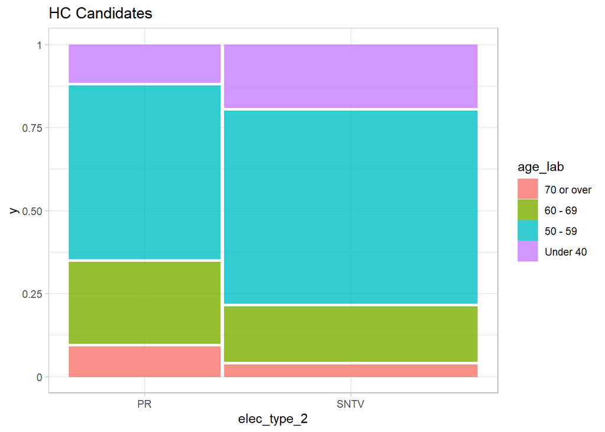

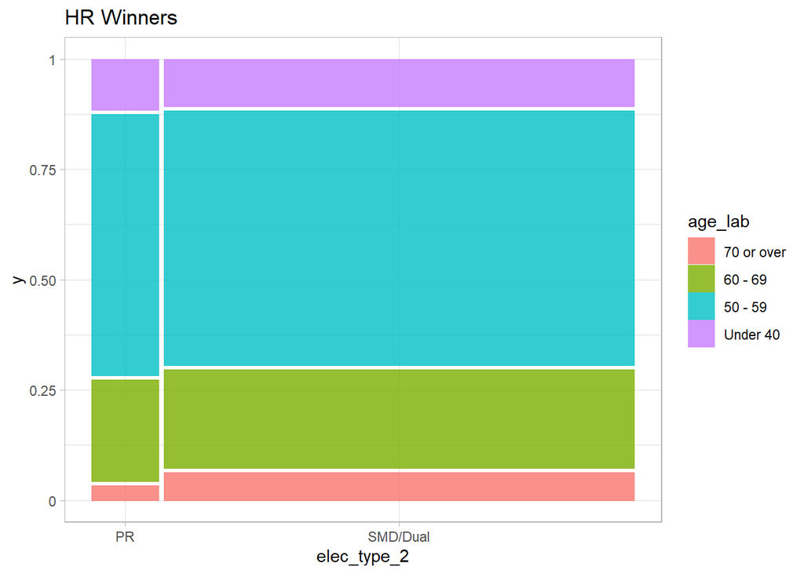

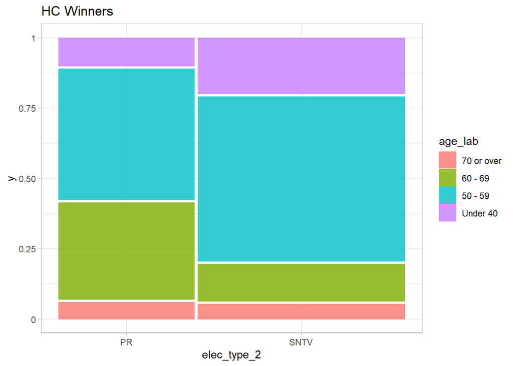

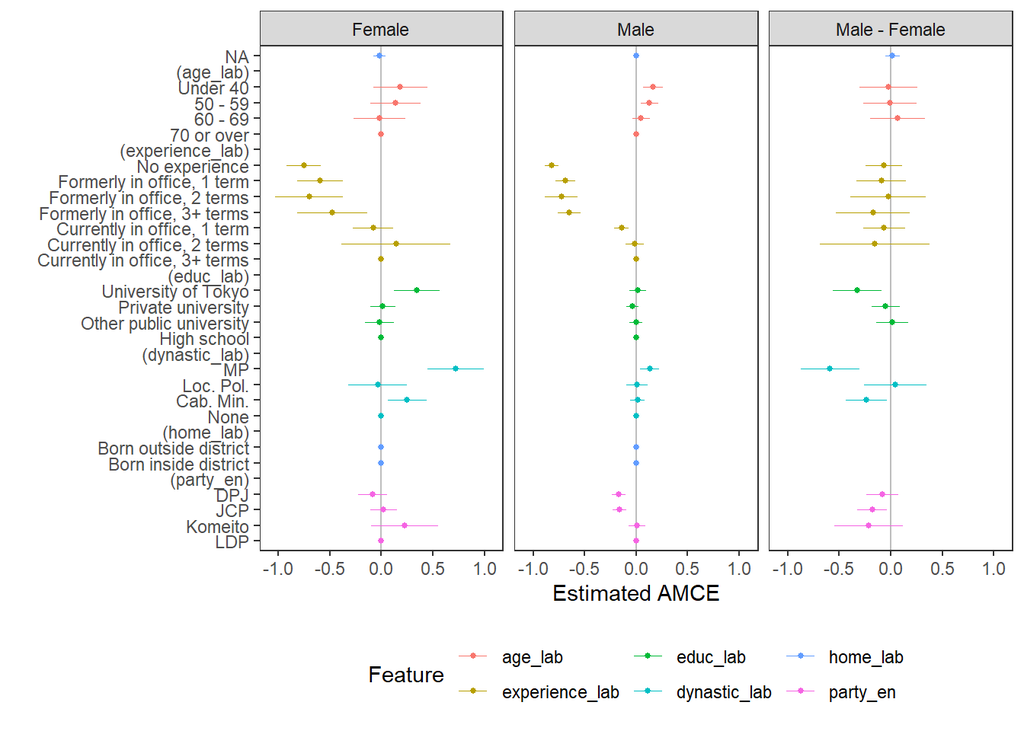